# Interdisciplinary investigations of the immune system:

25 January, 2017

## By the numbers:

## 25,000 genes

## 200 compatibility genes

## 6 class I HLA genes

## Who, what and when:

## 1936 Peter Gorer

## 1940s and WWII

## 1958 HLA gene identified

### Thousands have been idenitified to date

## DNA, RNA and protein

### Possibility, potential and actual | Alleles and allotypes

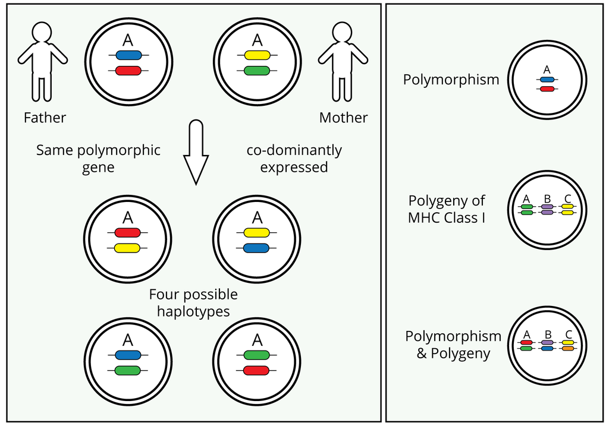

## 1986 Alain Townsend

### What HLA proteins are showing the immune system

## 1986 Tim Elliott

## 1987 Pamela Bjorkman

### The structure of the HLA protein

[figure not shown]

## 1990 to the present

### The peptide loading complex, peptide trimmers etc. etc.

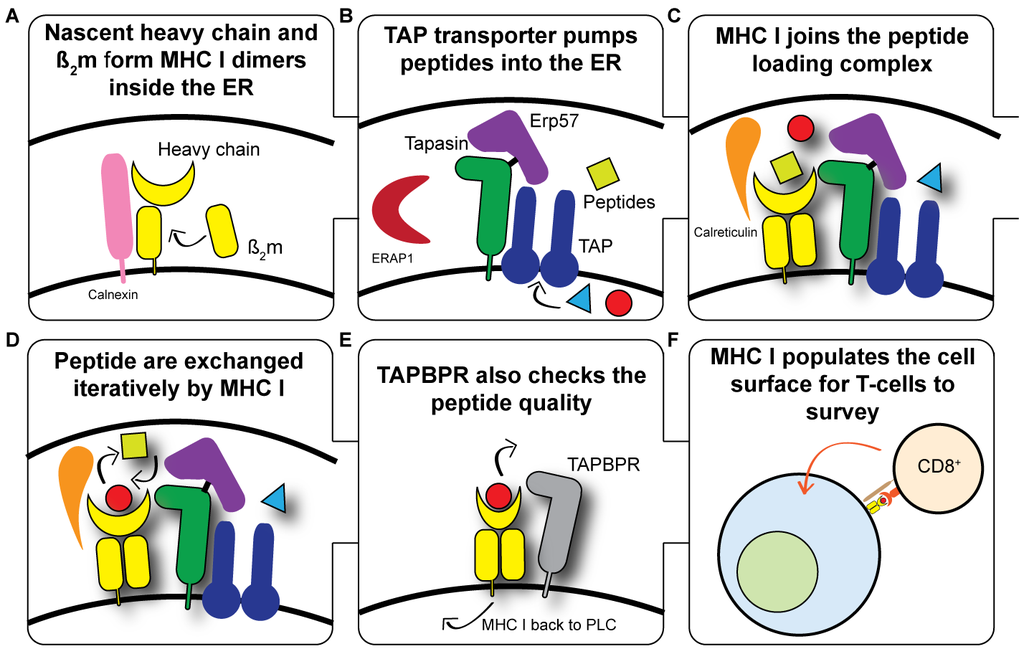

## Let's recap

### The known knowns

- There are thousands of these HLA genes
- We each have up to six
- HLA proteins present peptides
- And that's how T-cells know what is going inside cells

## Completing the Rumsfeld triplet

- We don't know the mechanism of peptide generation
- We don't know the mechanism of peptide selection by HLA
- We don't know what T-cells are seeing at any given time
- We don't know what we don't know

## 2008 to 2015

### Modelling HLA peptide selection

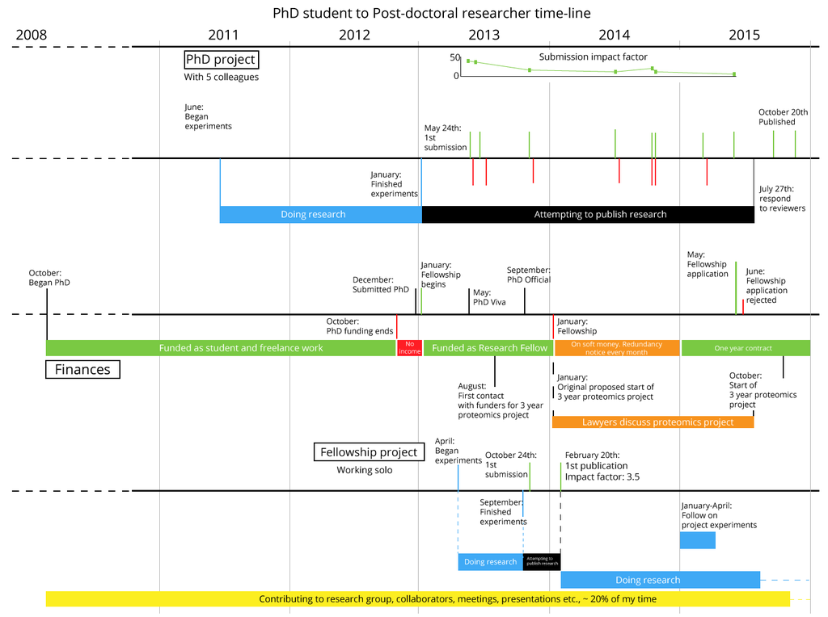

## Note to self :

### the low hanging fruit are gone…

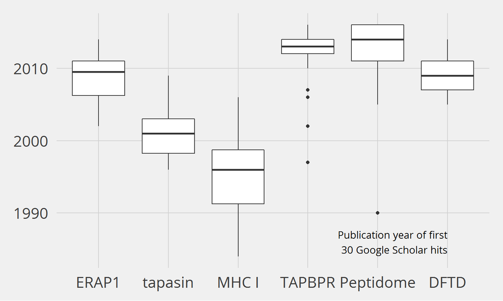

## Textbook vs. Real life

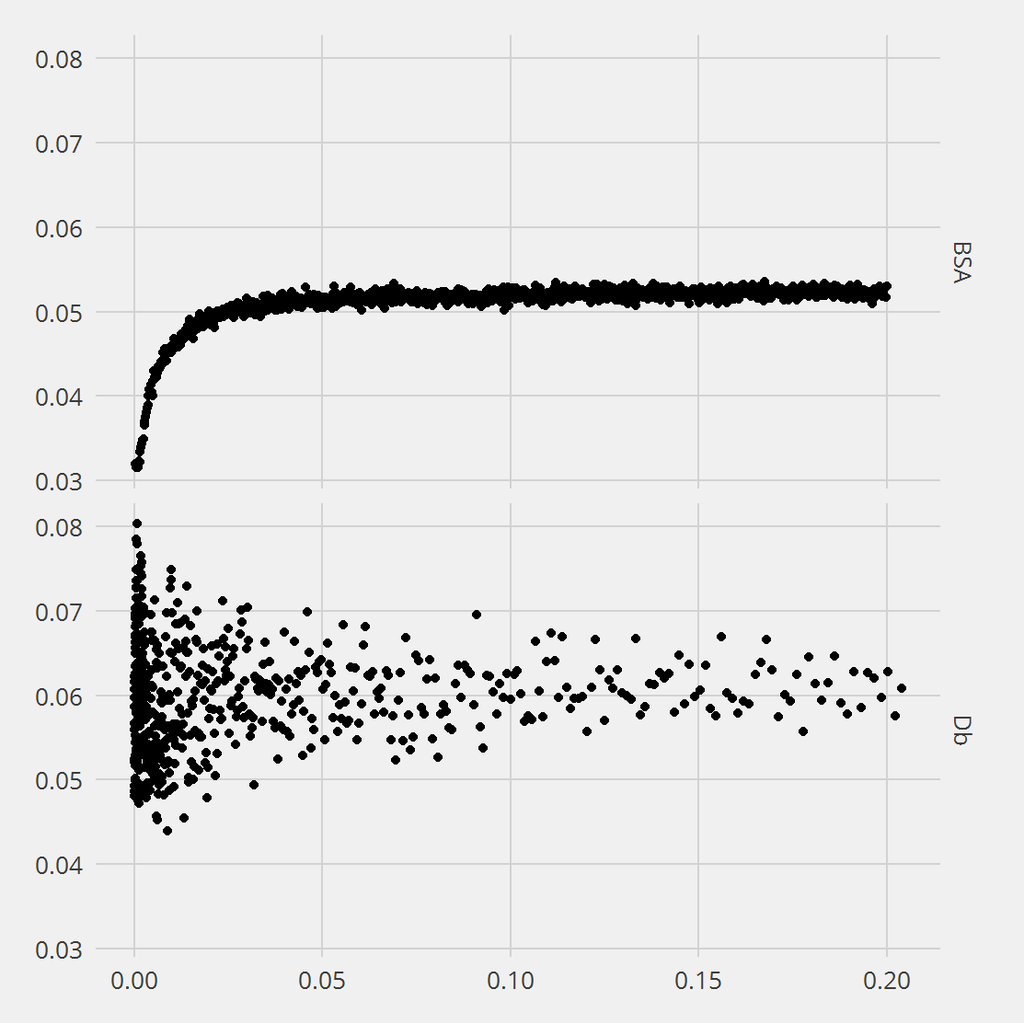

## Interdisciplinary science

### What is a contribution?

## Some lessons learnt

- Communication is fundamental.
- Ensure the question is clear. Invest in problem definition.
- Design and iterate the set of experiments and models as early as possible.
- Ideally, do the experiments as well as the analysis.

## Predicting HLA peptide selection

### Harnessing the power of the immune system

## Motivating observations

- HLA molecules select peptides faster than equilibrium kinetics predict.
- The higher stability the HLA complex, the more immunogenic it is.
- Removal of tapasin alters peptide selection in an allotype specific manner.

## HLA-B*44:02 and HLA-B*44:05

### one amino acid different

[figure not shown]

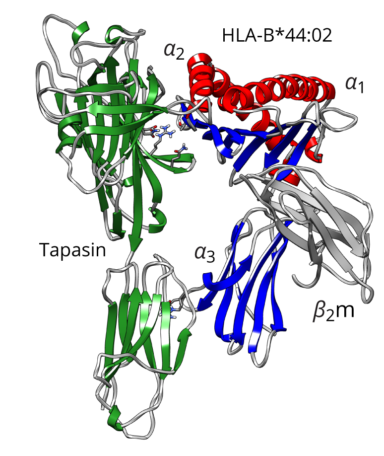

## A model of peptide selection

### Defining the system

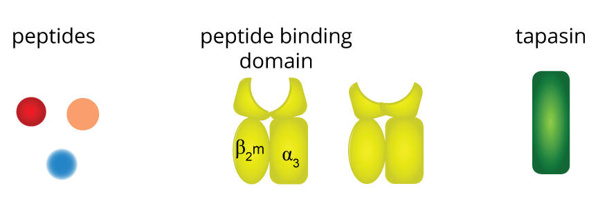

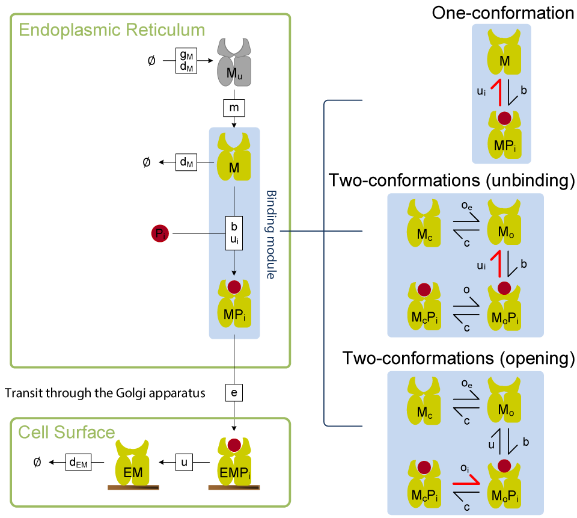

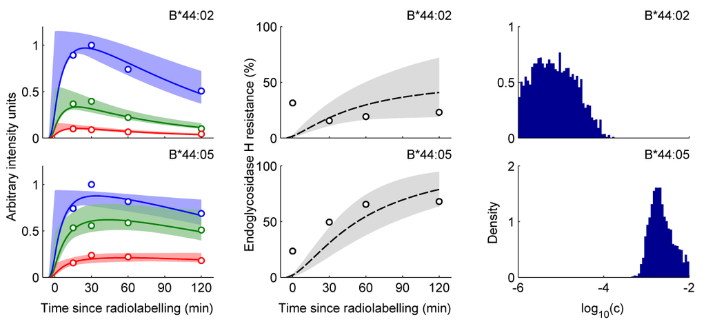

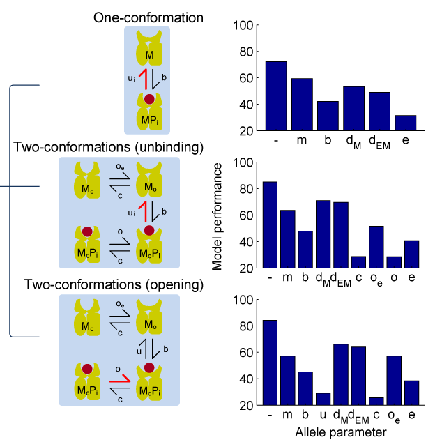

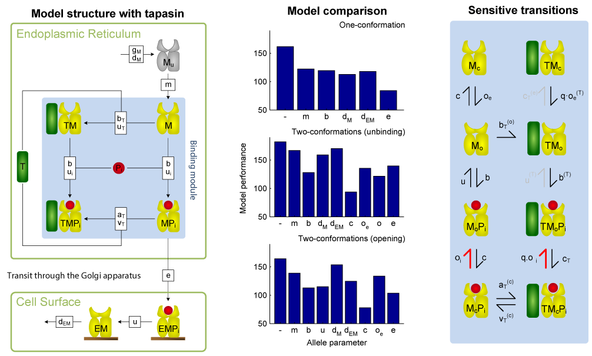

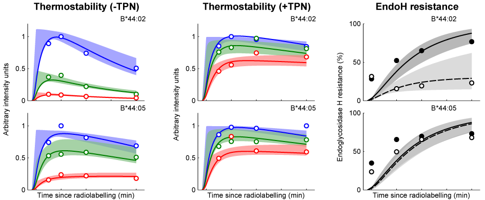

## Three predictions

- HLA allotype polymorphsims alter protein dynamics
- Tapasin modulates HLA dynamics to catalyse selection
- Peptide abundance can overide tapasin or allotype effect

## Let's recap again

- There are thousands of these HLA genes
- We each have up to six
- HLA proteins present peptides
- And that's how T-cells know what is going inside cells
- HLA molecules can change shape, they are plastic
- Protein plasticity is part of HLA function

## Predicting HLA peptide selection

### Harnessing the power of the immune system

- We need to know what the peptides are and how the population changes
- We need structural information on these intermediate states
- Therapies are likely to be stratified

## But wait, there's more!

The paper: doi:10.1038/srep14928

Email: ab604@soton.ac.uk

[ORCiD](http://orcid.org/0000-0003-0023-8679)

Book: The Compatability Gene by Dan Davis

## Who did the work

### and who paid for it

Rachel Darley - Experiments

[Neil Dalchau](https://www.microsoft.com/en-us/research/people/ndalchau/) - Mathematical model

[Tim Elliott](http://www.southampton.ac.uk/medicine/about/staff/tje.page), [Andrew Phillips](https://www.microsoft.com/en-us/research/people/aphillip/) and [Jörn Werner](http://www.southampton.ac.uk/biosci/about/staff/jmwe.page?) - Principal Investigators

[Microsoft Research](https://www.microsoft.com/en-us/research/group/biological-computation/) and the Medical Research Council - Funding